# AllLife Project

### Background and Context

AllLife Bank has a growing customer base. Majority of these customers are liability customers (depositors) with varying size of deposits. The number of customers who are also borrowers (asset customers) is quite small, and the bank is interested in expanding this base rapidly to bring in more loan business and in the process, earn more through the interest on loans. In particular, the management wants to explore ways of converting its liability customers to personal loan customers (while retaining them as depositors).

A campaign that the bank ran last year for liability customers showed a healthy conversion rate of over 9% success. This has encouraged the retail marketing department to devise campaigns with better target marketing to increase the success ratio with a minimal budget.

You as a Data scientist at AllLife bank has to build a model that will help marketing department to identify the potential customers who have higher probability of purchasing the loan. This will increase the success ratio while at the same time reduce the cost of the campaign.

### Objective

- To predict whether a liability customer will buy a personal loan or not.
- Which variables are most significant.
- Which segment of customers should be targeted more.

### Data Dictionary

- ID: Customer ID
- Age: Customer’s age in completed years
- Experience: #years of professional experience
- Income: Annual income of the customer (in thousand dollars)
- ZIP Code: Home Address ZIP code.
- Family: the Family size of the customer
- CCAvg: Avg. spending on credit cards per month (in thousand dollars)
- Education: Education Level. 1: Undergrad; 2: Graduate;3: Advanced/Professional
- Mortgage: Value of house mortgage if any. (in thousand dollars)
- Personal_Loan: Did this customer accept the personal loan offered in the last campaign?
- Securities_Account: Does the customer have securities account with the bank?
- CD_Account: Does the customer have a certificate of deposit (CD) account with the bank?
- Online: Do customers use internet banking facilities?
- CreditCard: Does the customer use a credit card issued by Universal Bank?

### 1.1 Load Libraries

```python
import numpy as np
import pandas as pd
import matplotlib.pyplot as plt
import seaborn as sns
from sklearn.tree import DecisionTreeClassifier
from sklearn.model_selection import train_test_split
from sklearn.metrics import confusion_matrix, classification_report
from sklearn.metrics import accuracy_score,precision_score,recall_score,f1_score
import scipy.stats as stats
from sklearn import metrics
from sklearn.model_selection import cross_val_score
from sklearn import tree
from sklearn.model_selection import GridSearchCV
from sklearn.linear_model import LogisticRegression
from sklearn import linear_model
from sklearn.preprocessing import StandardScaler
import statsmodels.api as sm
from statsmodels.stats.outliers_influence import variance_inflation_factor
from sklearn.metrics import roc_auc_score
from sklearn.metrics import roc_curve
from sklearn.metrics import accuracy_score
from mlxtend.feature_selection import SequentialFeatureSelector as SFS
from mlxtend.plotting import plot_sequential_feature_selection as plot_sfs

import warnings
warnings.filterwarnings('ignore') # To supress warnings
```

### 1.2. Import the dataset

```python
new_data  = pd.read_csv('Loan_Modelling.csv') # Import the dataset named Loan_Modelling.csv
data = new_data.copy()
data.head()  # view the first 5 rows of the data
```

|  | ID | Age | Experience | Income | ZIPCode | Family | CCAvg | Education | Mortgage | Personal_Loan | Securities_Account | CD_Account | Online | CreditCard |
| --- | --- | --- | --- | --- | --- | --- | --- | --- | --- | --- | --- | --- | --- | --- |
| 0 | 1 | 25 | 1 | 49 | 91107 | 4 | 1.6 | 1 | 0 | 0 | 1 | 0 | 0 | 0 |
| 1 | 2 | 45 | 19 | 34 | 90089 | 3 | 1.5 | 1 | 0 | 0 | 1 | 0 | 0 | 0 |
| 2 | 3 | 39 | 15 | 11 | 94720 | 1 | 1.0 | 1 | 0 | 0 | 0 | 0 | 0 | 0 |
| 3 | 4 | 35 | 9 | 100 | 94112 | 1 | 2.7 | 2 | 0 | 0 | 0 | 0 | 0 | 0 |
| 4 | 5 | 35 | 8 | 45 | 91330 | 4 | 1.0 | 2 | 0 | 0 | 0 | 0 | 0 | 1 |

```python
# We will go ahead and drop this column as we won't be using it
data.drop(['ID'],axis=1,inplace=True)
```

### 1.3 Check the Dimension of data

```python
data.shape # Check the shape of the data
```

```
(5000, 13)
```

### Observation

- There are 5,000 rows and 13 columns in this dataset

### 1.4 Check the Information about the data

```python
pd.DataFrame(data.isnull().sum(), columns= ['Number of missing values']) # Number of missing values in the data
```

|  | Number of missing values |
| --- | --- |
| Age | 0 |
| Experience | 0 |
| Income | 0 |
| ZIPCode | 0 |
| Family | 0 |
| CCAvg | 0 |
| Education | 0 |
| Mortgage | 0 |
| Personal_Loan | 0 |
| Securities_Account | 0 |
| CD_Account | 0 |
| Online | 0 |
| CreditCard | 0 |

```python
data.info() # Check information on the data
```

```
<class 'pandas.core.frame.DataFrame'>
RangeIndex: 5000 entries, 0 to 4999
Data columns (total 13 columns):
 #   Column              Non-Null Count  Dtype
---  ------              --------------  -----
 0   Age                 5000 non-null   int64
 1   Experience          5000 non-null   int64
 2   Income              5000 non-null   int64
 3   ZIPCode             5000 non-null   int64
 4   Family              5000 non-null   int64
 5   CCAvg               5000 non-null   float64
 6   Education           5000 non-null   int64
 7   Mortgage            5000 non-null   int64
 8   Personal_Loan       5000 non-null   int64
 9   Securities_Account  5000 non-null   int64
 10  CD_Account          5000 non-null   int64
 11  Online              5000 non-null   int64
 12  CreditCard          5000 non-null   int64
dtypes: float64(1), int64(12)
memory usage: 507.9 KB
```

```python
def check_value_counts(col): # Function to check value_counts
    print(data[col].value_counts())

for val in data.columns:
    check_value_counts(val)
```

```
35    151
43    149
52    145
58    143
54    143
50    138
41    136
30    136
56    135
34    134
39    133
59    132
57    132
51    129
60    127
```

[output cut: 151 more lines]

```python
data[data.duplicated()].count() # Check for duplicated rows
```

```
Age                   0
Experience            0
Income                0
ZIPCode               0
Family                0
CCAvg                 0
Education             0
Mortgage              0
Personal_Loan         0
Securities_Account    0
CD_Account            0
Online                0
CreditCard            0
dtype: int64
```

### 1.5 Data Pre-Processing & Feature Engineering

```python
# Replace negative values with 0.
def rep(df,val):
    df.loc[df['Experience'] == val, 'Experience'] = 0

rep(data,-1)
rep(data,-2)
rep(data,-3)
```

```python
# Multiply values by 1000 to get actual USD value
def mul_USD(val):
    return val * 1000

cols = ['Income','CCAvg','Mortgage']
for colname in cols:
    data[colname] = data[colname].apply(mul_USD)
```

```python
#Convert object columns to category datatype
categories = ['Family', 'Education','Personal_Loan','Securities_Account','CD_Account','Online','CreditCard']
data = data.apply(lambda col: col.astype('category') if col.name in categories else col)
```

```python
data.head()
```

|  | Age | Experience | Income | ZIPCode | Family | CCAvg | Education | Mortgage | Personal_Loan | Securities_Account | CD_Account | Online | CreditCard |
| --- | --- | --- | --- | --- | --- | --- | --- | --- | --- | --- | --- | --- | --- |
| 0 | 25 | 1 | 49000 | 91107 | 4 | 1600.0 | 1 | 0 | 0 | 1 | 0 | 0 | 0 |
| 1 | 45 | 19 | 34000 | 90089 | 3 | 1500.0 | 1 | 0 | 0 | 1 | 0 | 0 | 0 |
| 2 | 39 | 15 | 11000 | 94720 | 1 | 1000.0 | 1 | 0 | 0 | 0 | 0 | 0 | 0 |
| 3 | 35 | 9 | 100000 | 94112 | 1 | 2700.0 | 2 | 0 | 0 | 0 | 0 | 0 | 0 |
| 4 | 35 | 8 | 45000 | 91330 | 4 | 1000.0 | 2 | 0 | 0 | 0 | 0 | 0 | 1 |

### 1.6 Descriptive Analysis of Quantitative Variables

```python
data.describe() # Five(5) number summary of the quantitative variables
```

|  | Age | Experience | Income | ZIPCode | CCAvg | Mortgage |
| --- | --- | --- | --- | --- | --- | --- |
| count | 5000.000000 | 5000.000000 | 5000.000000 | 5000.000000 | 5000.00000 | 5000.000000 |
| mean | 45.338400 | 20.119600 | 73774.200000 | 93169.257000 | 1937.93800 | 56498.800000 |
| std | 11.463166 | 11.440484 | 46033.729321 | 1759.455086 | 1747.65898 | 101713.802102 |
| min | 23.000000 | 0.000000 | 8000.000000 | 90005.000000 | 0.00000 | 0.000000 |
| 25% | 35.000000 | 10.000000 | 39000.000000 | 91911.000000 | 700.00000 | 0.000000 |
| 50% | 45.000000 | 20.000000 | 64000.000000 | 93437.000000 | 1500.00000 | 0.000000 |
| 75% | 55.000000 | 30.000000 | 98000.000000 | 94608.000000 | 2500.00000 | 101000.000000 |
| max | 67.000000 | 43.000000 | 224000.000000 | 96651.000000 | 10000.00000 | 635000.000000 |

```python
data.describe(exclude=[np.number]) # Descriptive analysis of the qualitative variables
```

|  | Family | Education | Personal_Loan | Securities_Account | CD_Account | Online | CreditCard |
| --- | --- | --- | --- | --- | --- | --- | --- |
| count | 5000 | 5000 | 5000 | 5000 | 5000 | 5000 | 5000 |
| unique | 4 | 3 | 2 | 2 | 2 | 2 | 2 |
| top | 1 | 1 | 0 | 0 | 0 | 1 | 0 |
| freq | 1472 | 2096 | 4520 | 4478 | 4698 | 2984 | 3530 |

```python
# Function to Calculate the Coefficient of Variation
def coef_var(col):
    return round(data[col].std()/data[col].mean() * 100, 3)

columns = ['Age','Experience','Income','CCAvg','Mortgage','ZIPCode']
for colname in columns:
    cf = coef_var(colname)
    print('The coefficient of variation for', colname, 'is :' , cf, '%')
```

```
The coefficient of variation for Age is : 25.284 %
The coefficient of variation for Experience is : 56.862 %
The coefficient of variation for Income is : 62.398 %
The coefficient of variation for CCAvg is : 90.181 %
The coefficient of variation for Mortgage is : 180.028 %
The coefficient of variation for ZIPCode is : 1.888 %
```

### Observations

The five number summary helps describe the centre, spread and shape of the data

- The means of 'Income','CCAvg','Mortgage' are greater than the median which suggests a right skewed distribution.
- The coefficient of variation lets us know how spread out values are in relation to the mean. Mortgage has CVs greater than 100% which suggests that the data is widely spread. What this means is that there are outliers within this variable and a decision on how to treat them would depend on the model that would be used.
- From the summary, we can see that most customers did not accept the loan offered during the last campaign
- These assumptions would be validated later in this project

### 1.7 Exploratory Data Analysis (Univariate Analysis)

```python
# Function to create Histogram and Boxplot Visualizations
def hist_box(variable, bins, xlabel):
    plt.figure(figsize=(6,3)) # set the figure size
    sns.distplot(variable, bins=bins) # Plot the histogram

    plt.axvline(variable.mean(),color='green',label='Mean') # Draw lines on the plot for mean and median of the variable
    plt.axvline(variable.median(),color='blue',label='Median')

    plt.xlabel(xlabel) # label the x-axis
    plt.ylabel('Frequency') # label the y-axis
    plt.legend() # Plot the legend
    plt.title('Measure of Central Tendency and Dispersion') # Display plot title
    plt.show() # Display Plot

    plt.figure(figsize=(6,3)) # set the figure size
    sns.boxplot(variable) # Plot BoxPlot
```

### Visualization of Central Tendency and Dispersion Using Histogram & Boxplot (Age)

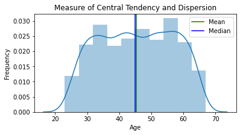

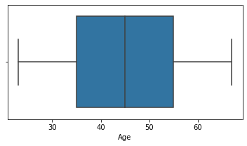

```python
hist_box(data['Age'], 10, 'Age')
```

### Observations

- Age of customers is normally distributed with the mean and median being very similar to each other
- The average age of loan customers is about 45 years old

### Visualization of Central Tendency and Dispersion Using Histogram & Boxplot (Experience)

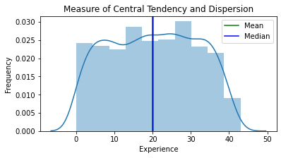

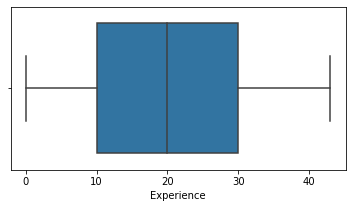

```python
hist_box(data['Experience'], 10, 'Experience')
```

### Observations

- This variable is normally distributed with the customers average years of experience being 20 years.

### Visualization of Central Tendency and Dispersion Using Histogram & Boxplot (Income)

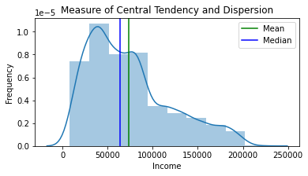

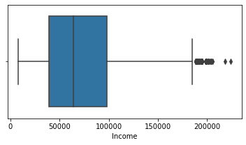

```python
hist_box(data['Income'], 10, 'Income')
```

### Visualization of Central Tendency and Dispersion Using Histogram & Boxplot (CCAvg)

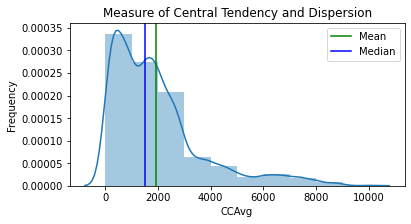

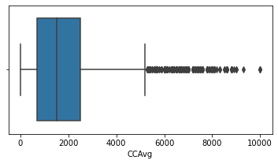

```python
hist_box(data['CCAvg'], 10, 'CCAvg')
```

### Visualization of Central Tendency and Dispersion Using Histogram & Boxplot (Mortgage)

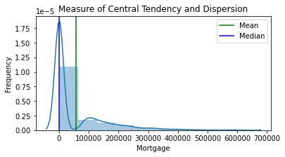

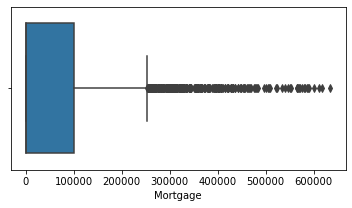

```python
hist_box(data['Mortgage'], 10, 'Mortgage')
```

### Observations

- On average, most customers do not make mortgage payments. There are however some customers whose payments range from 100,000 dollars to over 600,000 dollars

```python
# Function to create barplots that indicate percentage for each category.

def perc_on_bar(plot, feature):

    total = len(feature) # length of the column
    for p in ax.patches:
        percentage = '{:.1f}%'.format(100 * p.get_height()/total) # percentage of each class of the category
        x = p.get_x() + p.get_width() / 2 - 0.05 # width of the plot
        y = p.get_y() + p.get_height()           # hieght of the plot
        ax.annotate(percentage, (x, y), size = 12) # annotate the percantage
    plt.show() # show the plot
```

### Visualization of Categorical Variables Using Barplot (Family)

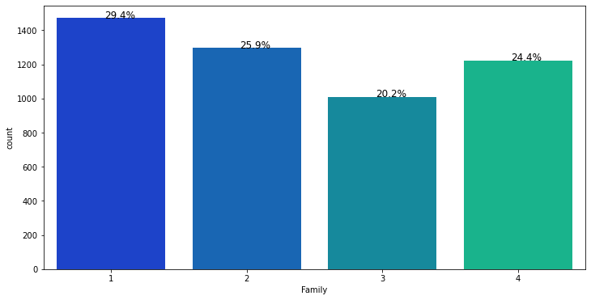

```python
# Plot barplot for Family Variable
plt.figure(figsize=(12,6)) # set the figure size
ax = sns.countplot(data['Family'],palette='winter')
perc_on_bar(ax,data['Family'])
```

### Observations

- 29.4% of customers have a family size of just 1 while customers with a family size of 3 are the least frequent in the company's customer base

### Visualization of Categorical Variables Using Barplot (Education)

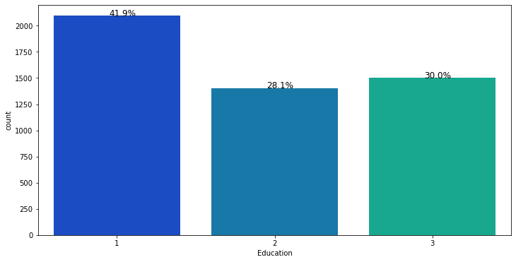

```python
# Plot barplot for Education Variable
plt.figure(figsize=(12,6)) # set the figure size
ax = sns.countplot(data['Education'],palette='winter')
perc_on_bar(ax,data['Education'])
```

### Observations

- 41.9% of the banks customers have their highest level of education being undergraduate degree.
- Customers with Graduate and Advanced degrees are split pretty evenly

### Visualization of Categorical Variables Using Barplot (Personal_Loan)

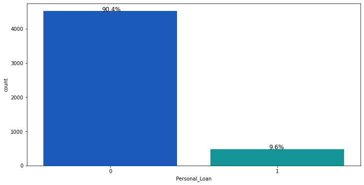

```python
# Plot barplot for Personal_Loan Variable
plt.figure(figsize=(12,6)) # set the figure size
ax = sns.countplot(data['Personal_Loan'],palette='winter')
perc_on_bar(ax,data['Personal_Loan'])
```

### Observations

- AllLife Bank had a healthy conversion rate of 9.6% during their last personal loan marketing campaign.
- As this is our dependent variable, the positive and negative split will be:
  - *Positive Class (1)*: Liability customers bought a loan during the last marketing campaign
  - *Negative Class (0)*: Liability customers did not buy a loan during the last marketing campaign

### Visualization of Categorical Variables Using Barplot (Securities_Account)

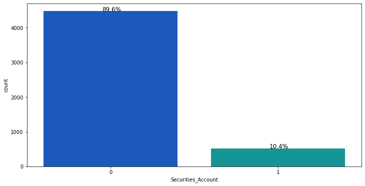

```python
# Plot barplot for Securities_Account Variable
plt.figure(figsize=(12,6)) # set the figure size
ax = sns.countplot(data['Securities_Account'],palette='winter')
perc_on_bar(ax,data['Securities_Account'])
```

### Visualization of Categorical Variables Using Barplot (CD_Account)

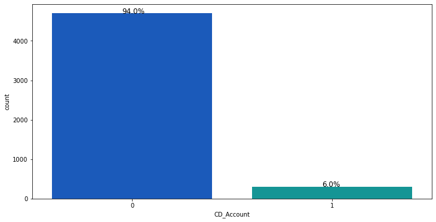

```python
# Plot barplot for CD_Account Variable
plt.figure(figsize=(12,6)) # set the figure size
ax = sns.countplot(data['CD_Account'],palette='winter')
perc_on_bar(ax,data['CD_Account'])
```

### Visualization of Categorical Variables Using Barplot (Online)

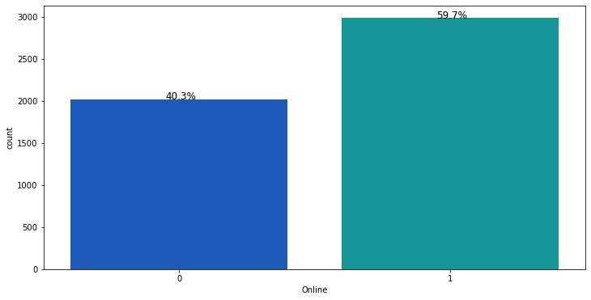

```python
# Plot barplot for Online Variable
plt.figure(figsize=(12,6)) # set the figure size
ax = sns.countplot(data['Online'],palette='winter')
perc_on_bar(ax,data['Online'])
```

### Visualization of Categorical Variables Using Barplot (CreditCard)

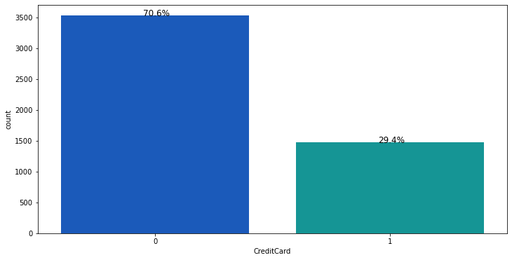

```python
# Plot barplot for CreditCard Variable
plt.figure(figsize=(12,6)) # set the figure size
ax = sns.countplot(data['CreditCard'],palette='winter')
perc_on_bar(ax,data['CreditCard'])
```

### Observations

- From the Securities_Account, Personal_Loan and CD_Account, Online, CreditCard plots, we can see that there has not been a very high adoption of products the bank introduces with an exception of Online Banking services. This suggests that the bank may need to rework its marketing strategy to convert more customers.

### 1.8 Exploratory Data Analysis (Bivariate Analysis)

### HeatMap

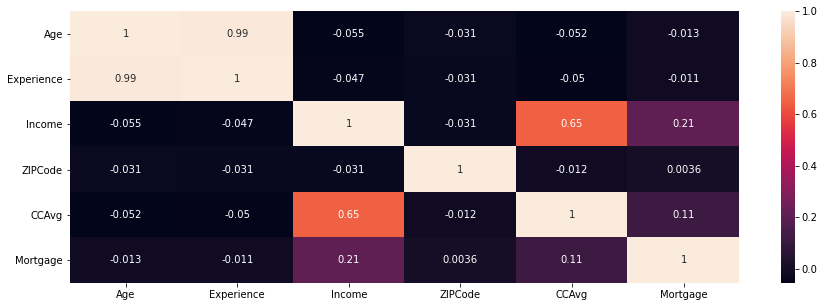

```python
# Diaplay Heatmap of numerical variables
plt.figure(figsize=(15,5))
sns.heatmap(data.corr(),annot=True)
plt.show()
```

### Observations

- There are not many correlations amongst variables within this dataset.
- There is however a very strong correlation between Age and Experience which suggests that the older the customer, the more likely that he/she has many years of work experience and vice versa. This is very logical and represents reality.
- There is also a high correlation between Income and Average Spending on Credit Card per month (CCAvg) which suggests that the higher the customers income, the more available money there is for customers to cover credit card bills monthly.
- These correlations will be validated with visualizations in the next section

### Personal_Loan vs Age

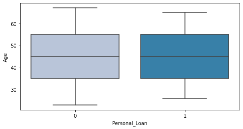

```python
plt.figure(figsize=(8,4)) # Adjust size
sns.boxplot(data["Personal_Loan"],data["Age"],palette="PuBu") #Plot Boxplot
plt.show() #display plot
```

### Personal_Loan vs Experience

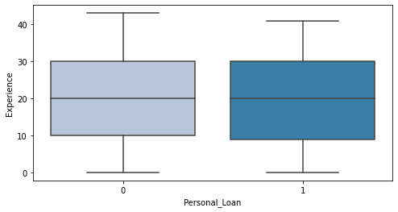

```python
plt.figure(figsize=(8,4)) # Adjust size
sns.boxplot(data["Personal_Loan"],data["Experience"],palette="PuBu") #Plot Boxplot
plt.show() #display plot
```

### Observations

- There isnt much difference in the average age and experience of customers who accepted the loan offer and customers who didnt accept the offer.

### Personal_Loan vs Income

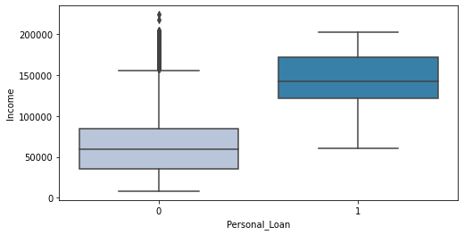

```python
plt.figure(figsize=(8,4)) # Adjust size
sns.boxplot(data["Personal_Loan"],data["Income"],palette="PuBu") #Plot Boxplot
plt.show() #display plot
```

### Observations

- Customers who accepted the loan offer have a higher income than customers who did not accept the loan.

### Personal_Loan vs CCAvg

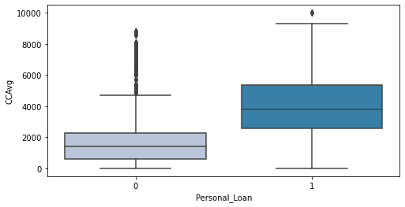

```python
plt.figure(figsize=(8,4)) # Adjust size
sns.boxplot(data["Personal_Loan"],data["CCAvg"],palette="PuBu") #Plot Boxplot
plt.show() #display plot
```

### Observations

- Customers who accepted the loan spend more on credit cards monthly.

### Personal_Loan vs Mortgage

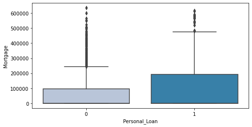

```python
plt.figure(figsize=(8,4)) # Adjust size
sns.boxplot(data["Personal_Loan"],data["Mortgage"],palette="PuBu") #Plot Boxplot
plt.show() #display plot
```

### Observations

- We can also see here that customers who did not accept the loan spend less on mortgages.

### Personal_Loan vs Family

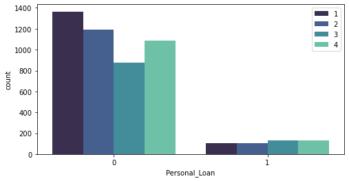

```python
plt.figure(figsize=(8,4))# Adjust size
sns.countplot(data["Personal_Loan"],hue=data["Family"],palette="mako") #Plot barplot
plt.legend(bbox_to_anchor=(1.00, 1))# Show legend
plt.show()#Display plot
```

### Observations

- Amongst those who did not accept the loan offer, there are more single family customers. while with those who did accept the loan offer, customers with family sizes of 3 and 4 make up the majority.

### Personal_Loan vs Education

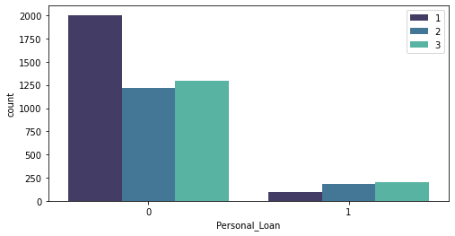

```python
plt.figure(figsize=(8,4))# Adjust size
sns.countplot(data["Personal_Loan"],hue=data["Education"],palette="mako") #Plot barplot
plt.legend(bbox_to_anchor=(1.00, 1))# Show legend
plt.show()#Display plot
```

### Observations

- Amongst those who did not accept the loan offer, a vast majority of the customers have an undergraduate degree. From those who did accept the loan offer, there are slightly more customers with an advanced degree than graduate degree

### Personal_Loan vs Securities_Account

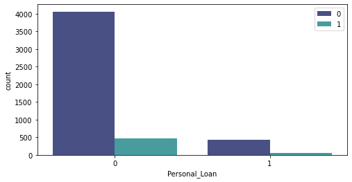

```python
plt.figure(figsize=(8,4))# Adjust size
sns.countplot(data["Personal_Loan"],hue=data["Securities_Account"],palette="mako") # Plot barplot
plt.legend(bbox_to_anchor=(1.00, 1))# Show legend
plt.show()# Display plot
```

### Personal_Loan vs CD_Account

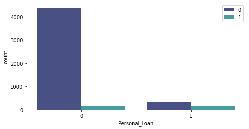

```python
plt.figure(figsize=(8,4))# Adjust size
sns.countplot(data["Personal_Loan"],hue=data["CD_Account"],palette="mako") # Plot barplot
plt.legend(bbox_to_anchor=(1.00, 1))# Show legend
plt.show()# Display plot
```

### Observations

- Amongst customers who did not accept the loan, a large proportion of them also do not have a securities account and also a CD account with the bank.

### Personal_Loan vs Online

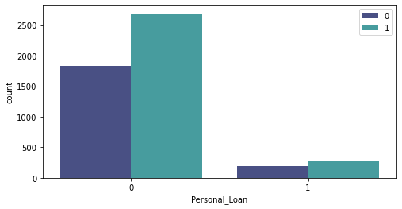

```python
plt.figure(figsize=(8,4)) # Adjust size
sns.countplot(data["Personal_Loan"],hue=data["Online"],palette="mako") # Plot barplot
plt.legend(bbox_to_anchor=(1.00, 1)) # Show legend
plt.show() # Display plot
```

### Observations

- Most of AllLife banks customers tend to subscribe to the banks online banking service regardless of whether they accepted the loan offer or not

### Personal_Loan vs CreditCard

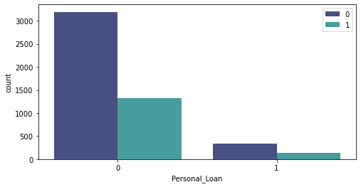

```python
plt.figure(figsize=(8,4)) # Adjust size
sns.countplot(data["Personal_Loan"],hue=data["CreditCard"],palette="mako") # Plot barplot
plt.legend(bbox_to_anchor=(1.00, 1)) # Show legend
plt.show() # Display plot
```

### Observations

- Most of the banks customers do not use a credit card issued by the bank

### Education vs Family

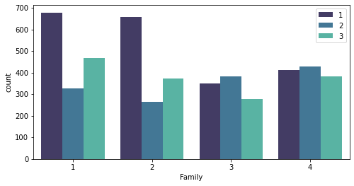

```python
plt.figure(figsize=(8,4)) # Adjust size
sns.countplot(data["Family"],hue=data["Education"],palette="mako") # Plot barplot
plt.legend(bbox_to_anchor=(1.00, 1)) # Show legend
plt.show() # Display plot
```

### Observations

- There are more Customers with undergraduate degrees amongst those with a family size of 1 and 2
- Customers with a family size of 3 and 4 have more customers with graduated degrees. Which means that the larger the family size, the more likely they are to have higher levels of education

### 1.9 Exploratory Data Analysis (Multivariate Analysis)

### Age vs Experience vs Personal Loan

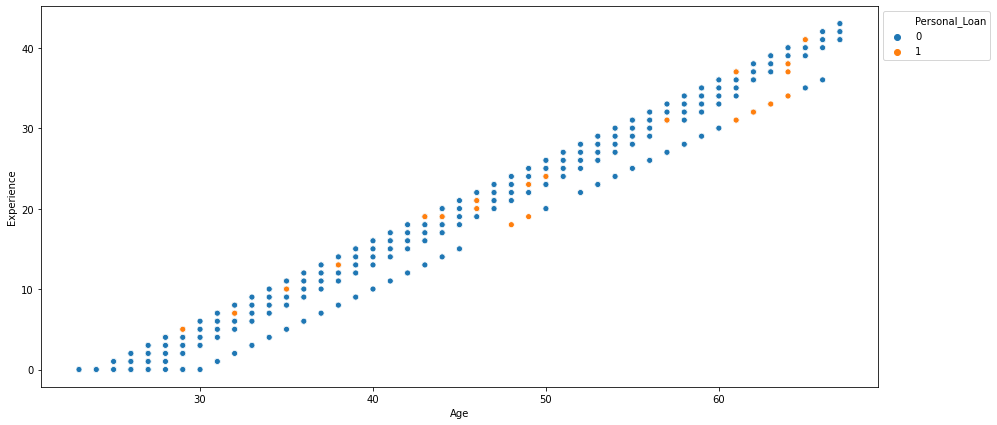

```python
plt.figure(figsize=(15,7)) #Adjust size
sns.scatterplot(data["Age"],data["Experience"],hue=data["Personal_Loan"],ci=0) # Plot scatter plot
plt.legend(bbox_to_anchor=(1.00, 1))# Show legend
plt.show()#Display plot
```

### Observations

- There is a very strong linear relationship between age and experience as earlier seen.

### Age vs Income vs Personal Loan

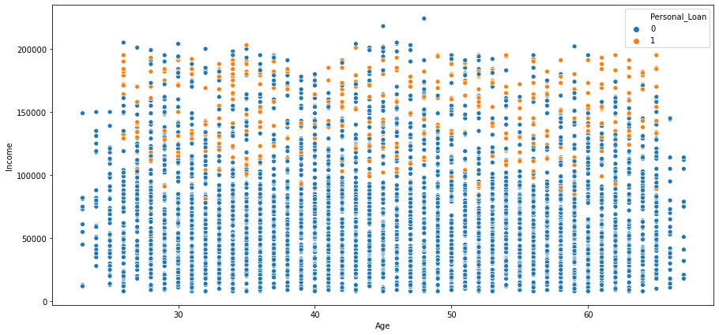

```python
plt.figure(figsize=(15,7)) #Adjust size
sns.scatterplot(data["Age"],data["Income"],hue=data["Personal_Loan"],ci=0) # Plot scatter plot
plt.legend(bbox_to_anchor=(1.00, 1))# Show legend
plt.show()#Display plot
```